# A Document

Jane Doe

1/23/2021

## R Markdown output

There are two different basic output formats available, document and presentation. As of this writing, the list of specific output types includes:

- `beamer_presentation`
- `context_document`
- `github_document`
- `html_document`
- `ioslides_presentation`
- `latex_document`
- `md_document`
- `odt_document`
- `pdf_document`
- `powerpoint_presentation`
- `rtf_document`
- `slidy_presentation`
- `word_document`

Various packages can also specify their own output types, e.g., `bookdown::html_document2` or `tufte::tufte_html.

### R Markdown rendering to specific formats

Remdering R Markdown files is done at the R console using the `rmarkdown::render()` function, e.g.,

```
rmarkdown::render(input = "input_filename.Rmd")
```

or by clicking the `Knit` control in RSTudio.

If the YAML header specifies multiple output formats, the first listed format will be used for the output if other options are not specified in the `render()` function call. For example, for this header, the default output format is `bookdown::html_document2`

```
---
title: "A Document"
author: "Jane Doe"
date: "2021-01-23"
output:
    bookdown::html_document2: default
    pdf_document: default
    html_document: default
    word_document: default
---
```

The RStudio interface will present the listed choices in the `Knit` pick list in the GUI, so the desired output format can be selected interactively:

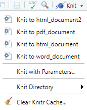

Other supported outputs can be created, including those that are not listed in the YAML header by specifying the output format in the `render()` function, e.g. to create a Slidy presentation:

```
rmarkdown::render(input = "input_filename.Rmd", output_format = "slidy_presentation")
```

To render a PDF file, use e.g.,

```
rmarkdown::render(input = "input_filename.Rmd", output_format = "pdf_document")
```

Using code rather than the RStudio GUI allows more flexible automation; you could have an R script that runs the `render()` function as part of a multi-step workflow. For example, if you had a continuous data collection process, the work flow could be coded and run with [cron](https://www.rdocumentation.org/packages/cronR) to generate a new PDF (or other file type) file on a daily basis.

### Testing `output_type()`

Because different output formats support (or do not support) different features, a test can be made for the output format to determine which code to run, using `is_html_output()` and `is_latex_output()`.

Here is an example; if the output is HTML, then a Leaflet map is added, along with the text “Because this is HTML output, a Leaflet map could be included!”

````
```{r, results='asis'}
if(is_html_output()){
    cat("Because this is HTML output, a Leaflet map could be included!")
        # the Space Needle
    snxy <- data.frame(name = "Space Needle", x = -122.3493, y = 47.6205)
    space_needle <- st_as_sf(snxy, coords = c("x", "y"), crs = 4326)

    # a leaflet
    m <- leaflet() %>%
        addTiles() %>%
        addCircleMarkers(data = space_needle)
    m
}
```
````

```r
if(is_latex_output()){
    cat("Because this is PDF output, no leaflet map could be included.")
}
```

## Advantages and disadvantages of PDF

Portable document format (PDF) has a number of advantages:

1. Document format is maintained. One of the problems with sharing documents made in Microsoft Word or other word processors is that when you share a file from one computer to the next, the formatting can prove to be very different. This can cause confusion, or make you look bad to your clients or colleagues. You can rest easier with the PDF format, that your document will be presented exactly how you layed it out. It’s also ideal for sending documents that are intended to be printed out.
2. The format is ubiquitous. Because it’s so good for what it sets out to do, PDF has been widely adopted all around the world. The format is easy to view and share, so whether you’re sharing a document with someone down the street, or on the other side of the world, PDF is a safe choice to send it in.
3. They tend to have a small file size in comparison to other formats. The TIFF file format has many benefits beyond PDF, but the PDF format has the big advantage of compressing high-quality files to a relatively small file size. That’s ideal for saving hard drive space, particularly if you’re working with limited storage resources.
4. The files can be protected by password. If you’re a business of any size, it’s possible, or even likely, that you’re handling some of your customers’ sensitive information. PDF files can be password-protected, giving you the ability make sure prying eyes are kept away from your important business documents.
5. It works on any operating system. PDF works on all the major operating systems currently in use. So whether the viewer is on a PC or a Mac, or even on a newer mobile operating system like iOS and Android, there’s almost no worry about the receiver being unable to view the document.
6. Easily integrate non-text elements (e.g. images, hyperlinks, etc.) PDFs allow you to maintain visually-pleasing layouts, and make use of links that will open up in the viewer’s web browser when viewing the documents on a computer or mobile device.
7. It’s not likely to go away. Technology moves quickly, but PDFs are probably here to stay for the long-haul. The format is so widespread and has so much history behind it that it would take a fundamental shift in computing for everyone to adopt a different standard. An investment in PDF software now is sure to stand up in the long run, and give your company an excellent return on investment.

The disadvantages: 1. Direct editing of PDF files is not straightforward (usually requires dedicated software), and often results in undesired layout changes. Therefore this is not a good format for collaborative editing. 1. Copy-and-paste from PDF often results in missing or extra spaces or strange characters. 1. R functions that produce HTML output cannot be used in PDF outputs.